# Assignment2

HARIKIRAN JHADE harikiran.21bce9514@vitapstudent.ac.in Morning slot(10-12) ASSIGNMENT-3 (AI & ML)

```python
# Importing Seaborn and matplotlib packages
import seaborn as sns
import matplotlib.pyplot as plt
```

```python
# Loading the car crashes dataset
df = sns.load_dataset('car_crashes')
```

```python
df.info()
```

```
<class 'pandas.core.frame.DataFrame'>
RangeIndex: 51 entries, 0 to 50
Data columns (total 8 columns):
 #   Column          Non-Null Count  Dtype
---  ------          --------------  -----
 0   total           51 non-null     float64
 1   speeding        51 non-null     float64
 2   alcohol         51 non-null     float64
 3   not_distracted  51 non-null     float64
 4   no_previous     51 non-null     float64
 5   ins_premium     51 non-null     float64
 6   ins_losses      51 non-null     float64
 7   abbrev          51 non-null     object
dtypes: float64(7), object(1)
memory usage: 3.3+ KB
```

```python
df.head()
```

|  | total | speeding | alcohol | not_distracted | no_previous | ins_premium | ins_losses | abbrev |
| --- | --- | --- | --- | --- | --- | --- | --- | --- |
| 0 | 18.8 | 7.332 | 5.640 | 18.048 | 15.040 | 784.55 | 145.08 | AL |
| 1 | 18.1 | 7.421 | 4.525 | 16.290 | 17.014 | 1053.48 | 133.93 | AK |
| 2 | 18.6 | 6.510 | 5.208 | 15.624 | 17.856 | 899.47 | 110.35 | AZ |
| 3 | 22.4 | 4.032 | 5.824 | 21.056 | 21.280 | 827.34 | 142.39 | AR |
| 4 | 12.0 | 4.200 | 3.360 | 10.920 | 10.680 | 878.41 | 165.63 | CA |

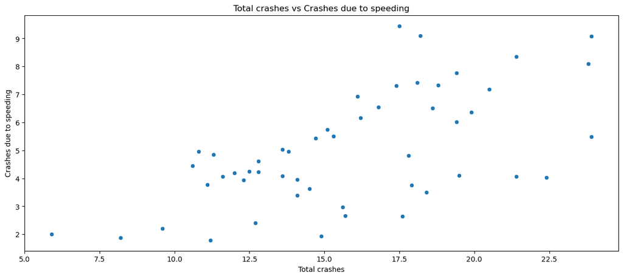

```python
# Scatter plot
plt.figure(figsize=(15, 6))
sns.scatterplot(x='total', y='speeding', data=df)
plt.xlabel('Total crashes')
plt.ylabel('Crashes due to speeding')
plt.title('Total crashes vs Crashes due to speeding')
plt.show()
```

Inference - The scatterplot compares Total car crashes with the crashes due to speeding, The plot has a positive correlation and when there are more number of crashes, there are more number of speeding crashes

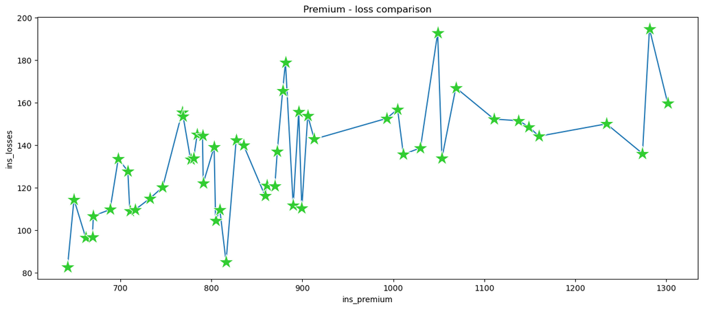

```python
# Line plot
plt.figure(figsize=(15, 6))
sns.lineplot(x='ins_premium', y ='ins_losses', data=df, marker='*', markerfacecolor='limegreen', markersize=20)
plt.xlabel('ins_premium')
plt.ylabel('ins_losses')
plt.title('Premium - loss comparison')
plt.show()
```

Inference- The above lineplot compares the insurance premium and insurance loss over the car crashes, From the plot it is clear that the maximum loss occurred for a insurance premium of 1300 and minimum loss is occurred for an insurance premium of 650 (approx.)

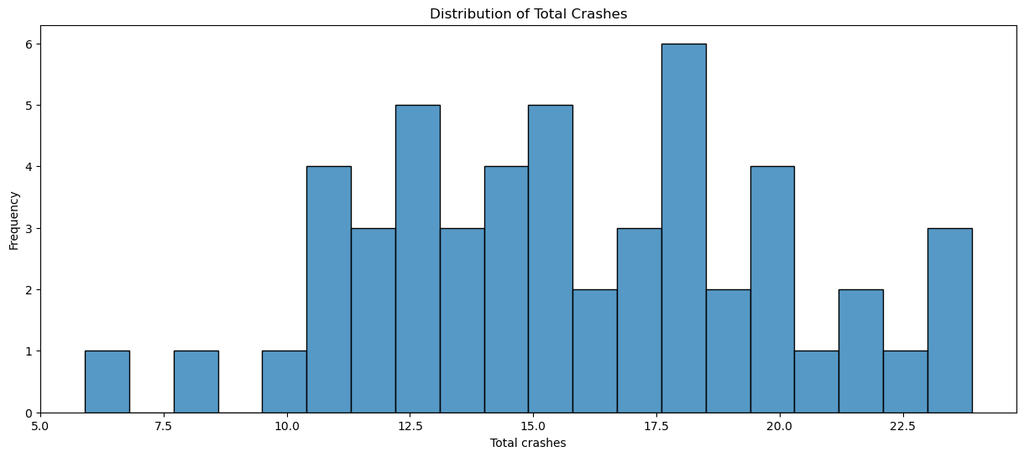

```python
# Histplot
plt.figure(figsize=(15, 6))
sns.histplot(df["total"], bins=20)
plt.title("Distribution of Total Crashes")
plt.xlabel("Total crashes")
plt.ylabel("Frequency")
plt.show()
```

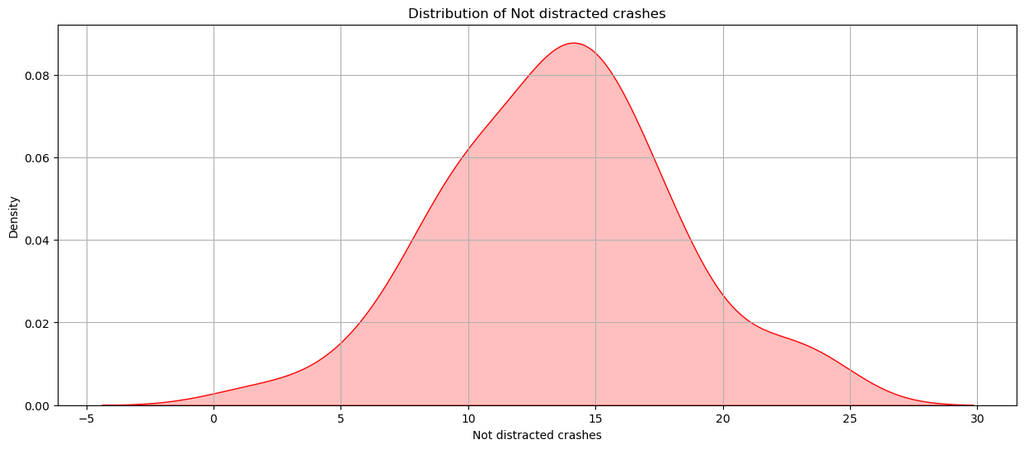

```python
#Kernel density plot
plt.figure(figsize=(15, 6))
sns.kdeplot(df["not_distracted"], fill = True,color='red',cbar=True)
plt.title("Distribution of Not distracted crashes")
plt.xlabel("Not distracted crashes")
plt.ylabel("Density")
plt.grid()
plt.show()
```

Inference- The above kernel density plot shows the density levels of notdistracted crashes of the data, The maximum density 0.09 is obtained for 13 not distracted crashes and there is high density for 10-20 number of crashes

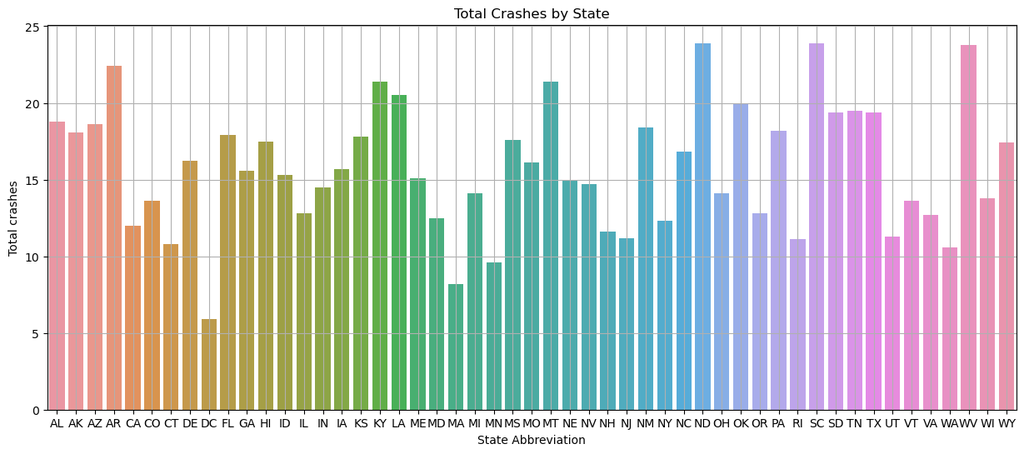

```python
#Barplot
plt.figure(figsize=(15, 6))
sns.barplot(x="abbrev", y="total", data=df, orient='v')
plt.title("Total Crashes by State")
plt.xlabel("State Abbreviation")
plt.ylabel("Total crashes")
plt.grid()
plt.show()
```

Inference- The barplot shows the total number of accidents by state, North Dakota, South Carolina & West Virginia have the highest number of accidents followed by Arkansas.

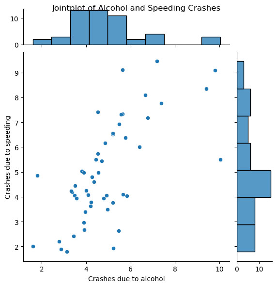

```python
#Jointplot
plt.figure(figsize=(15, 15))
sns.jointplot(x="alcohol", y="speeding", data=df, kind="scatter",marginal_ticks=True)
plt.suptitle("Jointplot of Alcohol and Speeding Crashes")
plt.xlabel("Crashes due to alcohol")
plt.ylabel("Crashes due to speeding")
plt.show()
```

Inference- The jointplot visually represents the relationship between alcohol and speeding crashes. It shows that as alcohol-related accidents increase, speeding-related accidents also tend to increase.

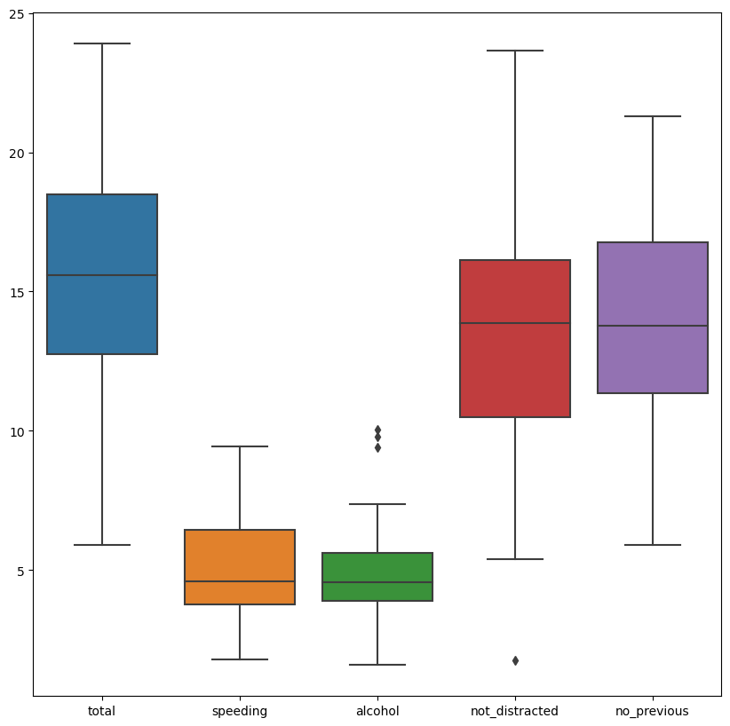

```python
#Boxplot
plt.figure(figsize=(10, 10))
sns.boxplot(df.iloc[:,0:5])
plt.show()
```

Inference- The boxplot of the dataset shows thath there are few outliers for number of crashes due to alcohol and not_ditracted crashes

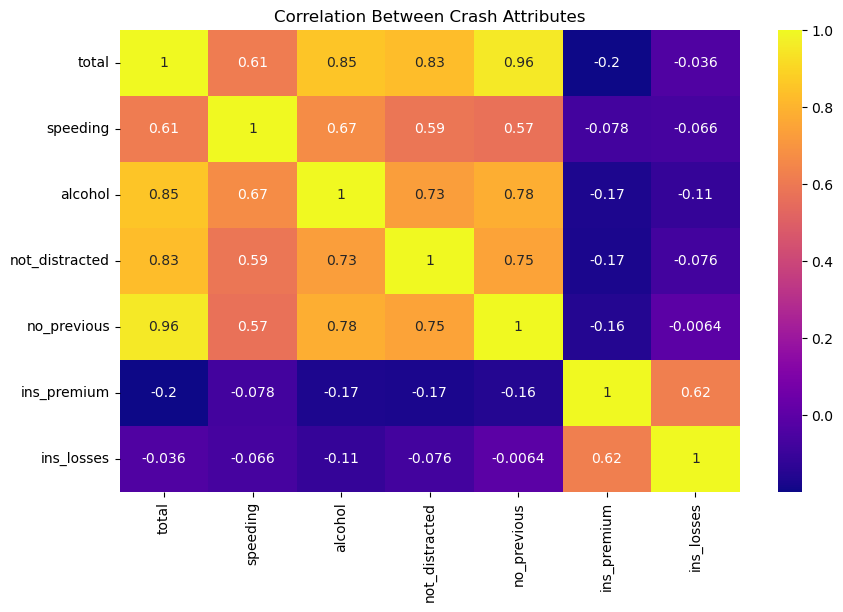

```python
#Heatmap
correlation_matrix = df.corr()
plt.figure(figsize=(10, 6))
sns.heatmap(correlation_matrix, annot=True, cmap="plasma")
plt.title("Correlation Between Crash Attributes")
plt.show()
```

Inference- The heatmap illustrating the correlation between crashes attributes shows that there is a positive correlation between some attributes

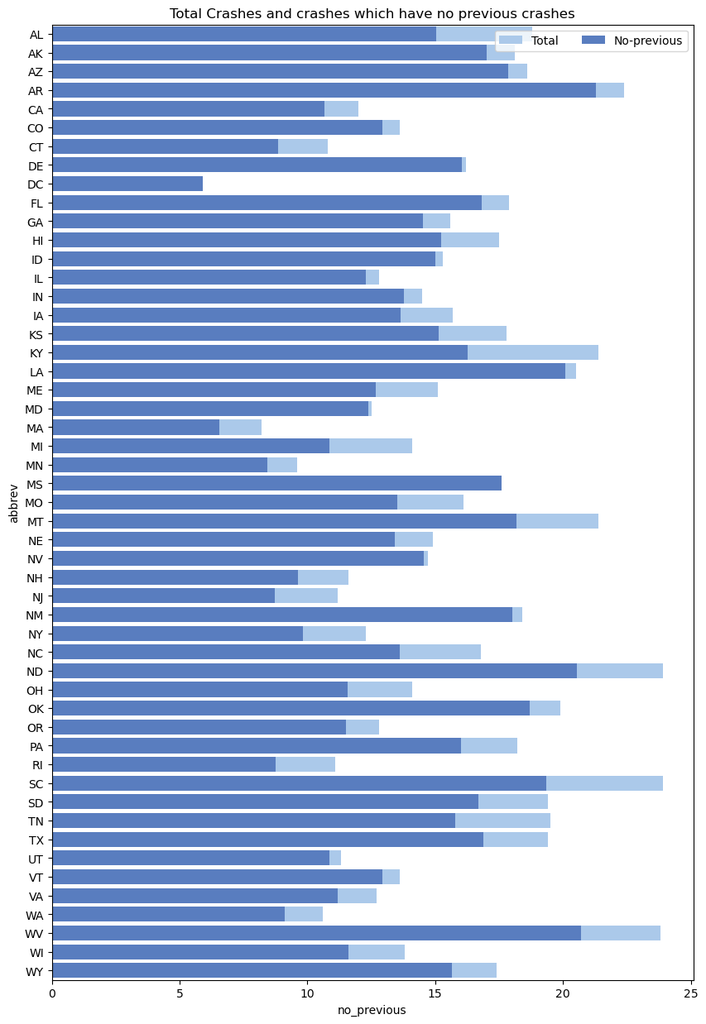

```python
# Stacked barchart
f, ax = plt.subplots(figsize=(10, 15))

# Plot the total crashes
sns.set_color_codes("pastel")
sns.barplot(x="total", y="abbrev", data=df ,label="Total", color="b")

# Plot the crashes who are not involved in previous crashes
sns.set_color_codes("muted")
sns.barplot(x="no_previous", y="abbrev", data=df, label="No-previous", color="b")
plt.title("Total Crashes and crashes which have no previous crashes")
ax.legend(ncol=2, loc="upper right", frameon=True)
```

Inference- The plot contains the bars of both total number of crashes and crashes with no previous crashes, It is clear that the total number of crashes is directly proportional to No previous crashes and More crashes that occur are having no previous crash history

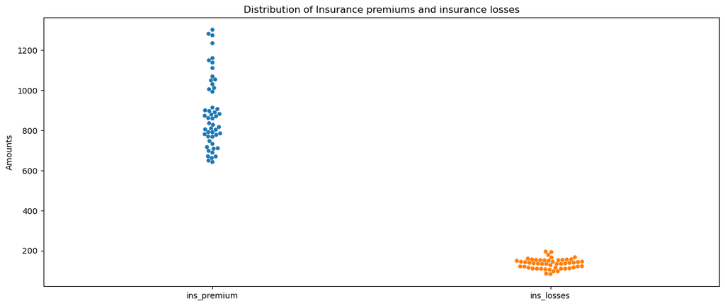

```python
# Swarm plot
plt.figure(figsize=(15, 6))
sns.swarmplot(df.iloc[:,5:7])
plt.title("Distribution of Insurance premiums and insurance losses")
plt.ylabel("Amounts")
plt.show()
```